# 머신러닝을 통한 단변수 환율예측 요약보고서

경제금융대학 2021206500 권순채

2021 12 23

# 연구개요

본 연구의 목적은 시계열 예측을 위한 머신러닝 모형의 예측력이 기존 시계열 모형(ARIMA모형)보다 뛰어난지 여부를 확인하는 것이다. 환율예측을 위한 방법으로 다변량과 단변량 분석을 고민하였으나 여러 변수 간 관계를 고려해야 하는 다변량 분석보다 과거 시계열 자료 학습만으로 미래 환율을 예측할 수 있는 단변량 분석을 채택하였다.

#### 분석에 필요한 라이브러리 실행

```r
library(jsonlite)
library('tidyverse')
library('lubridate')
```

```r
library(ggplot2)
library(tseries)
library(forecast)
library(TTR)
library(tsfknn)
```

# 데이터 수집: 한국은행 OPEN API 데이터 가져오기

분석에는 2000년 1월 4일부터 2021년 11월 30일까지의 일일 원/달러 환율을 활용하였으며 한국은행 Open Api를 통해 자료를 수집하였다.

```r
api_key = "9VP6FAXS12FXWAG9BLS9/"
file_type = "json/"
lang_type = "kr/"
start_no = "1/"
end_no ="7500/"
stat_code = "036Y001/"
cycle_type = "DD/"
start_date = "20000101/"
end_date = "20211130/"
item_no1 = "0000001/"
url = paste0("http://ecos.bok.or.kr/api/StatisticSearch/",
             api_key,file_type,lang_type,start_no,end_no,
             stat_code,cycle_type,start_date,end_date,item_no1)
raw.data <- readLines(url, warn = "F",encoding="UTF-8")
```

#### 데이터 전처리

분석을 위해 가져온 원자료를 전처리하는 과정이다.

```r
data1<- fromJSON(raw.data)
data1 <- as.data.frame(data1)
data2 <- data1[, c("StatisticSearch.row.DATA_VALUE", "StatisticSearch.row.TIME")]
wdrate <- data2[, c("StatisticSearch.row.DATA_VALUE")]
ymd <- data2[, c("StatisticSearch.row.TIME")]
ymd <-ymd(ymd)
wdrate <- as.numeric(as.character(wdrate))
df1 <- data.frame(ymd,wdrate)
```

## 시계열 그래프 시각화

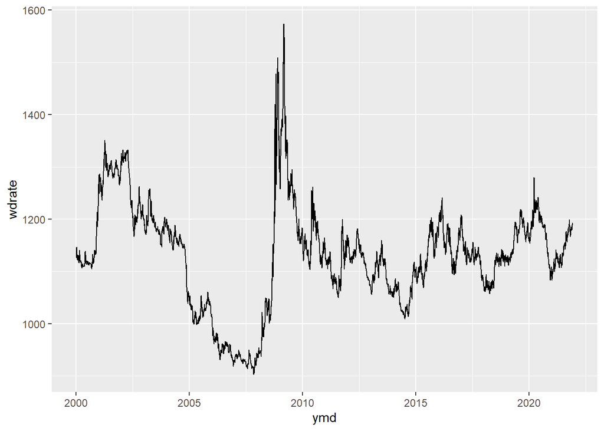

```r
ggplot(df1, aes(x=ymd,y=wdrate)) + geom_line()
```

#### 시계열 데이터 안정성 검정->안정적이지 않은 데이터

```r
adf.test(wdrate)
```

```
##
##  Augmented Dickey-Fuller Test
##
## data:  wdrate
## Dickey-Fuller = -2.7815, Lag order = 17, p-value = 0.2474
## alternative hypothesis: stationary
```

```r
adf.test(wdrate[1:5265])
```

```
##
##  Augmented Dickey-Fuller Test
##
## data:  wdrate[1:5265]
## Dickey-Fuller = -2.6947, Lag order = 17, p-value = 0.2842
## alternative hypothesis: stationary
```

#### 분석을 위해 데이터 1차차분 후 안정성 검정->안정적 데이터

```r
dif_wd <- diff(wdrate)
adf.test(dif_wd)
```

```
##
##  Augmented Dickey-Fuller Test
##
## data:  dif_wd
## Dickey-Fuller = -19.56, Lag order = 17, p-value = 0.01
## alternative hypothesis: stationary
```

#### 차분한 시계열 그래프 시각화

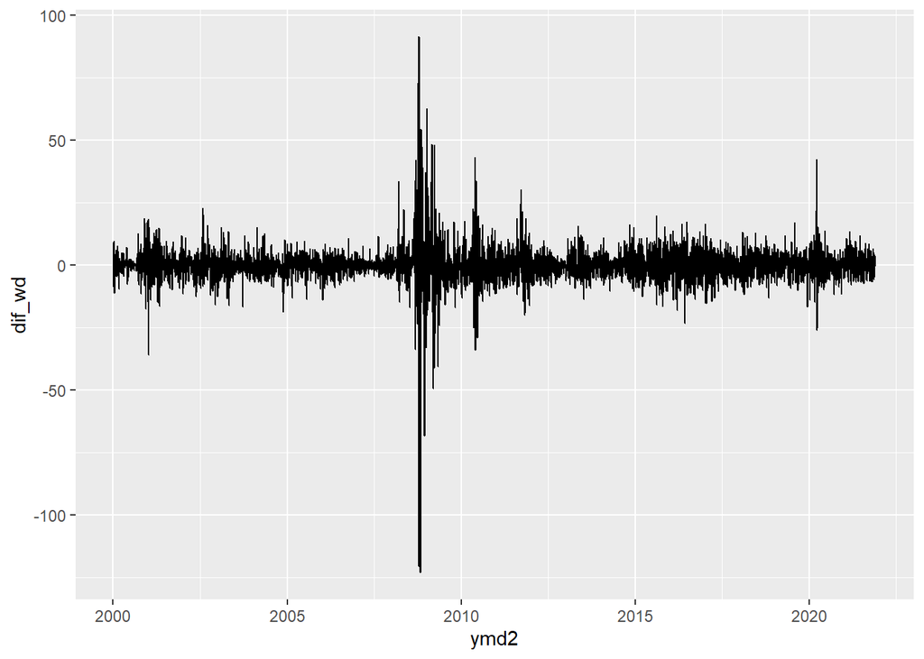

```r
ymd2 <- ymd[-c(1)]
df2 <- data.frame(ymd2,dif_wd)
ggplot(df2, aes(x=ymd2,y=dif_wd)) + geom_line()
```

#### 표본외 분석 및 예측력 비교를 위한 표본 분리

```r
training <- dif_wd[1:5265] #2000년~2019년 12월 31일
test<-dif_wd[5266:5740]    #2020년~2021년 11월 30일
```